# Homework 4

Connecticut Estate Sales Data

Joseph Farrell  
2022-02-25

**Load Libraries**

```r
library(readr)
library(tidyverse)
library(dplyr)
library(mosaic)
library(ggplot2)
```

**Read in data**

```r
connecticut <- read_csv("/Users/nelsonfarrell/Downloads/Real_Estate_Sales_2001-2019_GL.csv")
```

**Check variables of `connecticut`**

```r
str(connecticut)
```

```
spec_tbl_df [930,621 × 14] (S3: spec_tbl_df/tbl_df/tbl/data.frame)
 $ Serial Number   : num [1:930621] 141466 140604 14340 140455 141195 ...
 $ List Year       : num [1:930621] 2014 2014 2014 2014 2014 ...
 $ Date Recorded   : chr [1:930621] "08/06/2015" "06/29/2015" "07/01/2015" "04/30/2015" ...
 $ Town            : chr [1:930621] "Stamford" "New Haven" "Ridgefield" "New Britain" ...
 $ Address         : chr [1:930621] "83 OVERBROOK DRIVE" "56 HIGHVIEW LANE" "32 OVERLOOK DR" "171 BRADFORD WALK" ...
 $ Assessed Value  : num [1:930621] 503270 86030 351880 204680 229330 ...
 $ Sale Amount     : num [1:930621] 850000 149900 570000 261000 250000 ...
 $ Sales Ratio     : num [1:930621] 0.592 0.574 0.617 0.784 0.917 ...
 $ Property Type   : chr [1:930621] "Residential" "Residential" "Residential" "Residential" ...
 $ Residential Type: chr [1:930621] "Single Family" "Single Family" "Single Family" "Condo" ...
 $ Non Use Code    : chr [1:930621] NA NA NA NA ...
 $ Assessor Remarks: chr [1:930621] NA NA NA NA ...
 $ OPM remarks     : chr [1:930621] NA NA NA NA ...
 $ Location        : chr [1:930621] "POINT (-73.525969 41.081897)" "POINT (-72.878115 41.30285)" "POINT (-73.508273 41.286223)" "POINT (-72.775592 41.713335)" ...
 - attr(*, "spec")=
  .. cols(
  ..   `Serial Number` = col_double(),
  ..   `List Year` = col_double(),
  ..   `Date Recorded` = col_character(),
  ..   Town = col_character(),
  ..   Address = col_character(),
  ..   `Assessed Value` = col_double(),
  ..   `Sale Amount` = col_double(),
  ..   `Sales Ratio` = col_double(),
  ..   `Property Type` = col_character(),
  ..   `Residential Type` = col_character(),
  ..   `Non Use Code` = col_character(),
  ..   `Assessor Remarks` = col_character(),
  ..   `OPM remarks` = col_character(),
  ..   Location = col_character()
  .. )
 - attr(*, "problems")=<externalptr>
```

**Remove columns `Serial number`, `Non Use Code`, `Assessor Remarks`, `Sales Ratio`, and `OPM Remarks`**

```r
connecticut <- select(connecticut,
                      "List Year",
                      "Date Recorded",
                      "Town",
                      "Assessed Value",
                      "Sale Amount",
                      "Property Type",
                      "Residential Type",
                      "Location")
head(connecticut) #view first 6 rows of `connecticut`
```

```
# A tibble: 6 × 8
  `List Year` `Date Recorded` Town      `Assessed Value` `Sale Amount`
        <dbl> <chr>           <chr>                <dbl>         <dbl>
1        2014 08/06/2015      Stamford            503270        850000
2        2014 06/29/2015      New Haven            86030        149900
3        2014 07/01/2015      Ridgefie…           351880        570000
4        2014 04/30/2015      New Brit…           204680        261000
5        2014 06/26/2015      Stamford            229330        250000
6        2014 06/29/2015      West Har…           356300        600000
# … with 3 more variables: `Property Type` <chr>,
#   `Residential Type` <chr>, Location <chr>
```

**Rename colunms without spaces and for clarity**

```r
connecticut <- rename(connecticut,
                      "list_year" = "List Year",
                      "sale_date" = "Date Recorded",
                      "assessed_price" = "Assessed Value",
                      "sale_price" = "Sale Amount",
                      "property_type" = "Property Type",
                      "residential_type" = "Residential Type",
                      "location" = "Location",
                      "town" = "Town")
```

**List and description of remaining variables**

- `list_year`: numeric, year the property was listed
- `sale_date`: Date, date the property was sold
- `assessed_price`: numeric, price used in tax evaluation
- `sale_price`: numeric, price the property sold for
- `property_type`: character, nominal, type of property (i.e., residential, commercial, etc.)
- `residential_type`: character, nominal, if residential, type of residential (i.e., single family, two family, etc.)
- `location`: character, nominal, location of property in lat./long. (maybe useful to create a map later)
- `town`: character, nominal, town location property

**Potential Research Questions**

- Where are property values the highest?
- Where are property values the lowest?
- Where are property values increasing/decreasing?
- Are some areas trending higher while others trending lower?
- Are different types of property increasing/decreasing at different rates?
- Where should one buy a property and of what type to maximize increasing property value?

**Explore Data**

```r
head(connecticut)
```

```
# A tibble: 6 × 8
  list_year sale_date  town    assessed_price sale_price property_type
      <dbl> <chr>      <chr>            <dbl>      <dbl> <chr>
1      2014 08/06/2015 Stamfo…         503270     850000 Residential
2      2014 06/29/2015 New Ha…          86030     149900 Residential
3      2014 07/01/2015 Ridgef…         351880     570000 Residential
4      2014 04/30/2015 New Br…         204680     261000 Residential
5      2014 06/26/2015 Stamfo…         229330     250000 Residential
6      2014 06/29/2015 West H…         356300     600000 Residential
# … with 2 more variables: residential_type <chr>, location <chr>
```

```r
tail(connecticut)
```

```
# A tibble: 6 × 8
  list_year sale_date  town    assessed_price sale_price property_type
      <dbl> <chr>      <chr>            <dbl>      <dbl> <chr>
1      2014 02/19/2015 Hamden          220080     402500 Residential
2      2014 12/18/2014 Danbury         248500     428000 Residential
3      2014 11/20/2014 Naugat…         175910     252500 Residential
4      2014 01/21/2015 Bridge…         723600     466667 Commercial
5      2014 06/18/2015 Madison         409200     580000 Residential
6      2014 04/22/2015 Cheshi…         379100     520000 Residential
# … with 2 more variables: residential_type <chr>, location <chr>
```

**Convert `sale_date` from character to date**

```r
connecticut$sale_date <- as.Date(connecticut$sale_date,
                                 format = "%m/%d/%Y" )
str(connecticut)
```

```
tibble [930,621 × 8] (S3: tbl_df/tbl/data.frame)
 $ list_year       : num [1:930621] 2014 2014 2014 2014 2014 ...
 $ sale_date       : Date[1:930621], format: "2015-08-06" ...
 $ town            : chr [1:930621] "Stamford" "New Haven" "Ridgefield" "New Britain" ...
 $ assessed_price  : num [1:930621] 503270 86030 351880 204680 229330 ...
 $ sale_price      : num [1:930621] 850000 149900 570000 261000 250000 ...
 $ property_type   : chr [1:930621] "Residential" "Residential" "Residential" "Residential" ...
 $ residential_type: chr [1:930621] "Single Family" "Single Family" "Single Family" "Condo" ...
 $ location        : chr [1:930621] "POINT (-73.525969 41.081897)" "POINT (-72.878115 41.30285)" "POINT (-73.508273 41.286223)" "POINT (-72.775592 41.713335)" ...
```

**Explore `property_type` variable**

```r
tally(~property_type, data = connecticut)
```

```
property_type
             A     Apartments              C          C/I/U
          2210           2922              3          11913
    Commercial          Condo    Four Family     Industrial
         19404           9932            237           2551
Public Utility              R    Residential  Single Family
            66         290287         494147          40518
  Three Family     Two Family             UA              V
          1228           2411             11          24479
   Vacant Land           <NA>
         23414           4888
```

**Filter `property_type` for `Residential`, `Single Family`, `Two Family`, `Three Family`, `Condo`**

```r
connecticut <- connecticut %>%
  filter(`property_type` %in%
           c("Residential",
             "Single Family",
             "Two Family",
             "Three Family",
             "Condo"))
```

**Examine first and last 75 rows of `connecticut`**

```r
head(connecticut, n = 75)
```

```
# A tibble: 75 × 8
   list_year sale_date  town   assessed_price sale_price property_type
       <dbl> <date>     <chr>           <dbl>      <dbl> <chr>
 1      2014 2015-08-06 Stamf…         503270     850000 Residential
 2      2014 2015-06-29 New H…          86030     149900 Residential
 3      2014 2015-07-01 Ridge…         351880     570000 Residential
 4      2014 2015-04-30 New B…         204680     261000 Residential
 5      2014 2015-06-26 Stamf…         229330     250000 Residential
 6      2014 2015-06-29 West …         356300     600000 Residential
 7      2014 2014-10-17 Willi…         236060     332900 Residential
 8      2014 2015-08-05 Trumb…         183900     240000 Residential
 9      2014 2015-09-01 Water…          89610      75500 Residential
10      2014 2014-12-02 Water…          75840      91000 Residential
# … with 65 more rows, and 2 more variables: residential_type <chr>,
#   location <chr>
```

```r
tail(connecticut, n = 75)
```

```
# A tibble: 75 × 8
   list_year sale_date  town   assessed_price sale_price property_type
       <dbl> <date>     <chr>           <dbl>      <dbl> <chr>
 1      2014 2014-10-09 Groton         155610      83000 Residential
 2      2014 2015-04-01 Manch…         112300     164800 Residential
 3      2014 2015-07-30 Farmi…         449170     710000 Residential
 4      2014 2015-04-28 Harwi…         146430     185000 Residential
 5      2014 2015-05-19 Chesh…         266540     342000 Residential
 6      2014 2015-09-21 Darien         549990    3395000 Residential
 7      2014 2015-06-26 Hamden         148470     175000 Residential
 8      2014 2015-07-21 Killi…          73850     124900 Residential
 9      2014 2014-12-11 Brook…         240180     395000 Residential
10      2014 2015-07-16 Merid…         114170     108500 Residential
# … with 65 more rows, and 2 more variables: residential_type <chr>,
#   location <chr>
```

**Get summary statistics of `assessed_price` and `sale_price`**

```r
summarize(connecticut,
          mean_assessed_price = mean(assessed_price),
          mean_sale_price = mean(sale_price),
          median_assessed_price = median(assessed_price),
          median_sale_price = median(sale_price),
          sd_assessed_price =sd(assessed_price),
          sd_sale_price = sd(sale_price))
```

```
# A tibble: 1 × 6
  mean_assessed_pri… mean_sale_price median_assessed… median_sale_pri…
               <dbl>           <dbl>            <dbl>            <dbl>
1            247960.         349358.           159755           230000
# … with 2 more variables: sd_assessed_price <dbl>,
#   sd_sale_price <dbl>
```

**View favstats of `assessed_price`**

```r
favstats(~assessed_price, data = connecticut)
```

```
 min     Q1 median     Q3       max     mean      sd      n missing
   0 111000 159755 247270 881510000 247959.7 1292161 548236       0
```

**View favstats of `sale_price`**

```r
options(scipen = 999) # remove scientific notation
favstats(~sale_price, data = connecticut)
```

```
 min     Q1 median     Q3       max     mean       sd      n missing
   0 147500 230000 360000 120000000 349357.8 636067.5 548236       0
```

**Examine counts of `property_type`**

```r
table(select(connecticut, property_type))
```

```
        Condo   Residential Single Family  Three Family    Two Family
         9932        494147         40518          1228          2411
```

```r
connecticut %>%
  count(property_type)
```

```
# A tibble: 5 × 2
  property_type      n
  <chr>          <int>
1 Condo           9932
2 Residential   494147
3 Single Family  40518
4 Three Family    1228
5 Two Family      2411
```

**View proportions of `property type`**

```r
prop.table(table(select(connecticut, property_type)))
```

```
        Condo   Residential Single Family  Three Family    Two Family
  0.018116286   0.901339934   0.073906128   0.002239911   0.004397741
```

**View counts of `town` variable**

```r
connecticut %>%
  count(town) %>%
  arrange(desc(n))
```

```
# A tibble: 170 × 2
   town              n
   <chr>         <int>
 1 Bridgeport    18239
 2 Waterbury     15533
 3 Stamford      14678
 4 Norwalk       12698
 5 Fairfield     11340
 6 West Hartford 10750
 7 Danbury       10588
 8 Greenwich     10559
 9 Hamden        10318
10 New Haven     10133
# … with 160 more rows
```

**View proportions of `town` variable**

```r
options(scipen = 999) #remove scientific notation
prop.table(table(select(connecticut, town)))
```

```
   ***Unknown***          Andover          Ansonia          Ashford
  0.000001824032   0.000835406650   0.004607504797   0.001194740951
            Avon      Barkhamsted     Beacon Falls           Berlin
  0.007234110857   0.000906543897   0.001935297937   0.005915335731
         Bethany           Bethel        Bethlehem       Bloomfield
  0.001324247222   0.005667267381   0.000793453914   0.005625314646
          Bolton           Bozrah         Branford       Bridgeport
  0.001406328661   0.000512552988   0.009603528407   0.033268519397
     Bridgewater          Bristol       Brookfield         Brooklyn
  0.000541737500   0.016241180805   0.005570593686   0.002657614604
      Burlington           Canaan       Canterbury           Canton
  0.003239480808   0.000383046717   0.001364375926   0.003553214309
         Chaplin         Cheshire          Chester          Clinton
  0.000516201052   0.008085933795   0.001008689688   0.005059864730
      Colchester        Colebrook         Columbia         Cornwall
  0.004158792929   0.000443239773   0.001455577525   0.000465128156
        Coventry         Cromwell          Danbury           Darien
  0.003947205218   0.004755251388   0.019312850670   0.007179389898
      Deep River            Derby           Durham      East Granby
  0.001459225589   0.003368987079   0.002115877104   0.002083044528
     East Haddam     East Hampton    East Hartford       East Haven
  0.003026069065   0.004981431354   0.014707169905   0.008452564224
       East Lyme     East Windsor         Eastford           Easton
  0.006807287373   0.003575102693   0.000390342845   0.002571885101
       Ellington          Enfield            Essex        Fairfield
  0.004799028156   0.011383783626   0.002588301388   0.020684522724
      Farmington         Franklin      Glastonbury           Goshen
  0.008974237372   0.000397638973   0.012649661824   0.001293238678
          Granby        Greenwich         Griswold           Groton
  0.003463836742   0.019259953743   0.003319738215   0.009545159384
        Guilford           Haddam           Hamden          Hampton
  0.007166621674   0.002570061069   0.018820362034   0.000454183965
        Hartford         Hartland        Harwinton           Hebron
  0.013371978491   0.000490664604   0.001384440278   0.002467915277
            Kent        Killingly     Killingworth          Lebanon
  0.001050642424   0.006103211026   0.001920705681   0.002103108880
         Ledyard           Lisbon       Litchfield             Lyme
  0.005395486615   0.001067058712   0.002497099789   0.000802574074
         Madison       Manchester        Mansfield      Marlborough
  0.006544626767   0.014645152817   0.004071239393   0.001906113426
```

[output cut: 31 more lines]

```
  0.002145061616   0.002754288299   0.003834115235   0.013375626555
        Trumbull            Union           Vernon        Voluntown
  0.010712539855   0.000184227231   0.008335826177   0.000795277946
     Wallingford           Warren       Washington        Waterbury
  0.015137641454   0.000474248316   0.001530362836   0.028332688842
       Waterford        Watertown    West Hartford       West Haven
  0.006809111405   0.005497632406   0.019608343852   0.013371978491
       Westbrook           Weston         Westport     Wethersfield
  0.002624782028   0.003347098695   0.010915007406   0.008211792002
      Willington           Wilton       Winchester          Windham
  0.001130899831   0.005380894359   0.003514909637   0.005324349368
         Windsor    Windsor Locks          Wolcott       Woodbridge
  0.008587542591   0.004317483711   0.004704178492   0.002683151052
        Woodbury        Woodstock
  0.003044309385   0.002850961994
```

**View summary statistics of different `property_types`**

```r
connecticut %>%
  group_by(property_type) %>%
  summarize(mean_sale_price_type = mean(sale_price),
            median_sale_price_type = median(sale_price),
            sd_sale_price_type = sd(sale_price))
```

```
# A tibble: 5 × 4
  property_type mean_sale_price_type median_sale_pri… sd_sale_price_t…
  <chr>                        <dbl>            <dbl>            <dbl>
1 Condo                      238111.           177900          236357.
2 Residential                346711.           226000          645755.
3 Single Family              418460.           280000          602036.
4 Three Family               240900.           225000          157237.
5 Two Family                 243985.           205000          219448.
```

**View distribution of `sale price`, check for outliers**

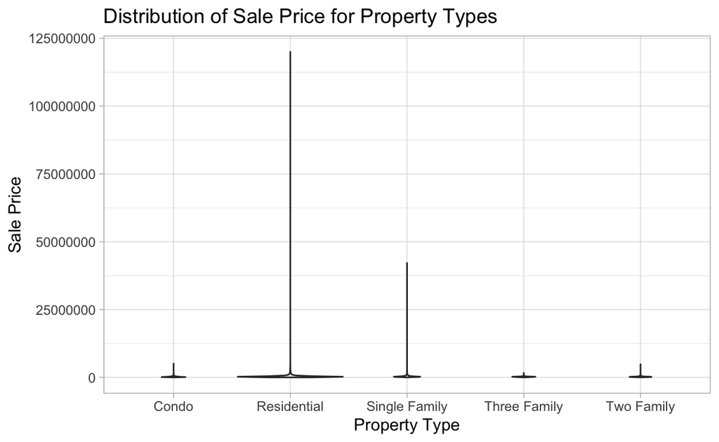

```r
connecticut %>%
  group_by(property_type) %>%
  ggplot(aes(x = property_type, y = sale_price)) +
  geom_violin(notch = TRUE) +
  labs(title = "Distribution of Sale Price for Property Types",
       x = "Property Type",
       y = "Sale Price") +
  theme_light()
```

**View distribution filtering `sale price` for under $2,500,000**

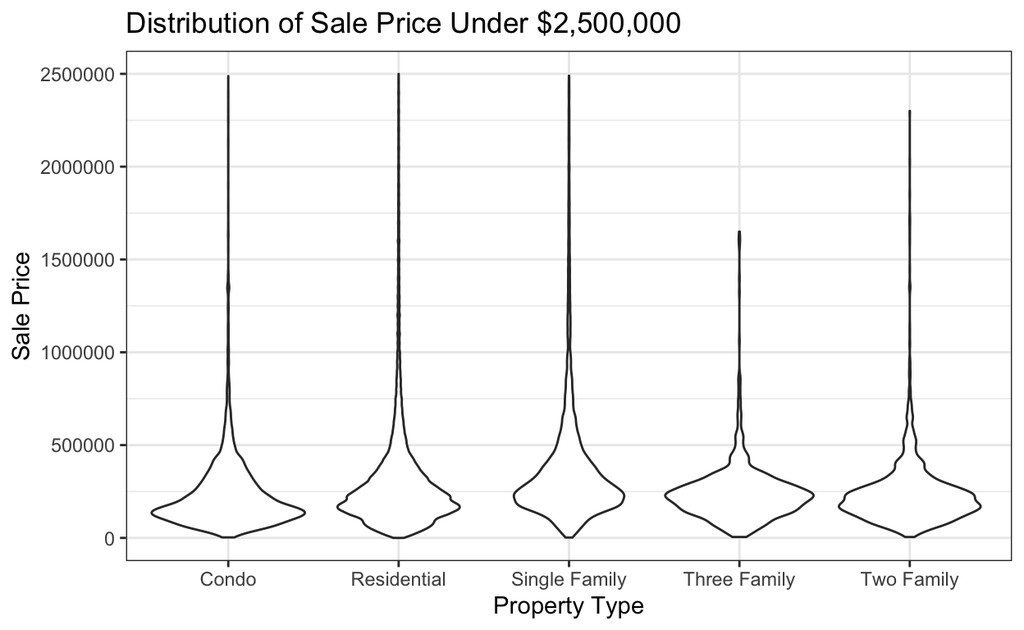

```r
connecticut %>%
  filter(`sale_price` < 2500000) %>%
  group_by(property_type) %>%
  ggplot(aes(x = property_type, y = sale_price)) +
  geom_violin(notch = TRUE) +
  labs(title = "Distribution of Sale Price Under $2,500,000",
       x = "Property Type",
       y = "Sale Price") +
  theme_bw()
```

**Create a bargraph of median `sale price` of each town in Connecticut**

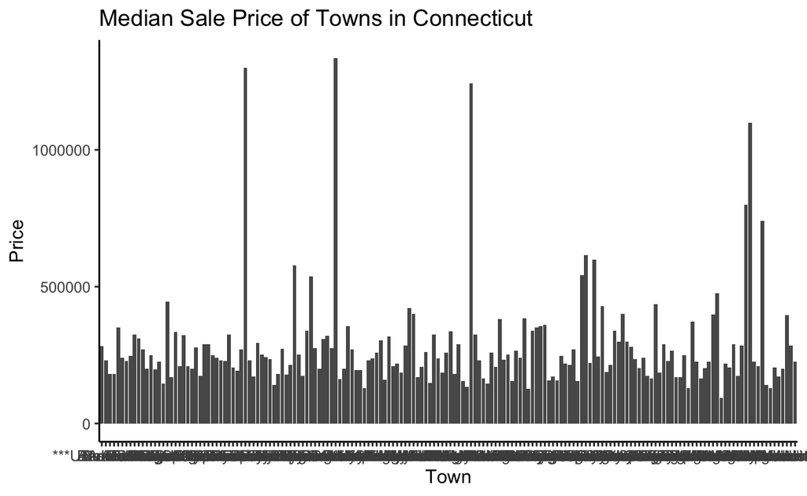

```r
connecticut %>%
  group_by(town) %>%
  summarize(median_sale_price = median(sale_price)) %>%
  ggplot(aes(x = town, y = median_sale_price)) +
  geom_bar(stat = "identity") +
  labs(title = "Median Sale Price of Towns in Connecticut",
       y = "Price",
       x = "Town") +
  theme_classic()
```

- The variables I am visualizing in this graphic are `town` and `median_sale_price`.
- The questions I am attempting to answer are:
  - What are the towns with highest median sale price?
  - What are the towns with lowest median sale price?
  - Is there is big difference between the towns?
- Conclusions:
  - I can conclude that there is a big difference in the median sale prices of different towns.
- Limitations of this visualization:
  - I cannot really distinguish which towns have high median sale prices are which are lower.
  - To a naive reader it would very unclear what I am attempting to accomplish because there are too many towns are the x-axis to get any idea what is going on in this graphic.
  - This could be improved by not including all the towns, and perhaps only including the top 10, middle 10, and bottom, potentially.

**Group by year and display median sale price**

```r
connecticut %>%
  group_by(year = lubridate::floor_date(sale_date, "year")) %>%
  summarize(median_yearly_sale_price = median(sale_price)) %>%
  arrange()
```

```
# A tibble: 20 × 2
   year       median_yearly_sale_price
   <date>                        <dbl>
 1 1999-01-01                   95000
 2 2001-01-01                  425856.
 3 2003-01-01                  158900
 4 2004-01-01                  286900
 5 2005-01-01                  150000
 6 2006-01-01                  260000
 7 2007-01-01                  270000
 8 2008-01-01                  240000
 9 2009-01-01                  215000
10 2010-01-01                  222100
11 2011-01-01                  210000
12 2012-01-01                  220000
13 2013-01-01                  220500
14 2014-01-01                  210000
15 2015-01-01                  214000
16 2016-01-01                  215000
17 2017-01-01                  227000
18 2018-01-01                  225000
19 2019-01-01                  230000
20 2020-01-01                  265000
```

```r
connecticut %>%
  group_by(year = lubridate::floor_date(sale_date, "year")) %>%
  arrange(year)
```

```
# A tibble: 548,236 × 9
# Groups:   year [20]
   list_year sale_date  town   assessed_price sale_price property_type
       <dbl> <date>     <chr>           <dbl>      <dbl> <chr>
 1      2017 1999-04-05 New L…          46690      95000 Residential
 2      2017 2001-08-23 Shelt…         427910     558000 Residential
 3      2017 2001-08-01 Shelt…         390810     635000 Residential
 4      2006 2001-09-04 Newin…          64750      88000 Residential
 5      2006 2001-10-27 Green…         573930     660000 Residential
 6      2006 2001-09-25 Nauga…         183850     293711 Residential
 7      2006 2001-09-05 Newin…         166110     256000 Residential
 8      2006 2003-07-17 Nauga…          84200     158900 Residential
 9      2006 2004-07-31 Newin…         246120     420000 Residential
10      2006 2004-06-05 Brist…         147320     329900 Residential
# … with 548,226 more rows, and 3 more variables:
#   residential_type <chr>, location <chr>, year <date>
```

**Create an object of the towns with bottom ten median sale prices**

```r
median_sale_price_bottom_10 <-connecticut %>%
  group_by(town) %>%
  summarize(median_sale_price = median(sale_price)) %>%
  arrange(median_sale_price) %>%
  slice(1:10)
```

**Create an object of the towns with the top ten median sale prices**

```r
median_sale_price_top_10 <-connecticut %>%
  group_by(town) %>%
  summarize(median_sale_price = median(sale_price)) %>%
  arrange(desc(median_sale_price)) %>%
  slice(1:10)
```

**View top and bottom 10 towns**

```r
median_sale_price_bottom_10
```

```
# A tibble: 10 × 2
   town          median_sale_price
   <chr>                     <dbl>
 1 Waterbury                 94300
 2 Norwich                  126140
 3 Torrington               128500
 4 Hartford                 130000
 5 Windham                  130000
 6 New Britain              134000
 7 East Hartford            140000
 8 Winchester               141000
 9 New London               145000
10 Bridgeport               146000
```

```r
median_sale_price_top_10
```

```
# A tibble: 10 × 2
   town       median_sale_price
   <chr>                  <dbl>
 1 Greenwich            1335000
 2 Darien               1300000
 3 New Canaan           1242591
 4 Westport             1100000
 5 Weston                799000
 6 Wilton                741000
 7 Ridgefield            614625
 8 Roxbury               600000
 9 Easton                577517
10 Redding               541975
```

**Create Vector of top 10 towns**

```r
top_10 <- median_sale_price_top_10$town
```

**Create a line graph of the top ten towns with the highest median sale prices**

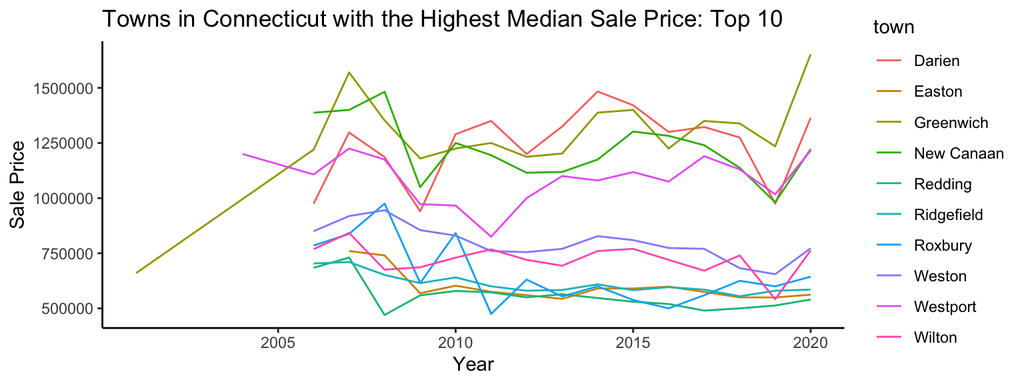

```r
connecticut %>%
  group_by(town, year = lubridate::floor_date(sale_date, "year")) %>%
  summarize(median_yearly_sale_price = median(sale_price)) %>%
  filter(town %in% top_10) %>%
  ggplot(aes(x = year, y = median_yearly_sale_price)) +
  geom_line(aes(color = town)) +
  ggtitle("Towns in Connecticut with the Highest Median Sale Price: Top 10") +
  ylab("Sale Price") +
  xlab("Year") +
  theme_classic()
```

**Same as above only facet wrapped**

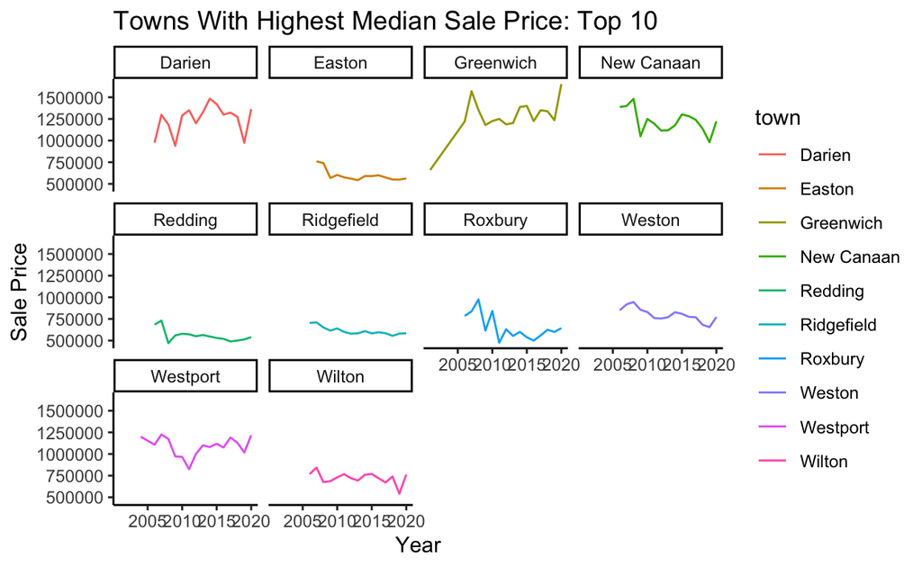

```r
connecticut %>%
  group_by(town, year = lubridate::floor_date(sale_date, "year")) %>%
  summarize(median_yearly_sale_price = median(sale_price)) %>%
  filter(town %in% top_10) %>%
  ggplot(aes(x = year, y = median_yearly_sale_price)) +
  geom_line(aes(color = town)) +
  ggtitle("Towns With Highest Median Sale Price: Top 10") +
  ylab("Sale Price") +
  xlab("Year") +
  theme_classic() +
  facet_wrap(vars(town))
```